# Part I: Decisions, distributions, data

Predictions: Theory and Practice

Content of Part I: Decisions, distributions, data

1. decision-making under uncertainty
   - decisions should be based on probability predictions
2. optimal predictions
   - What are good predictions?

# Decision-making under uncertainty

### Goals

- Understand **decision-making** under **uncertainty**
- show unique role of **probabilistic predictions**
- understand how to update beliefs with **Bayes rule**

## Introduction

### Event predictions

- We start by discussing predictions for **events**
  - events have two possible outcomes
  - here we will use 0 (“not happening”) and 1 (“happening”)
  - another nomenclature is event $E$ and its complement $E^c$
- Examples for events:
  - “Trump will be president in 2029”
  - “It will rain tomorrow”

### Some intuition

- How can an **event prediction** look like?
  - “The event will happen.”
  - “The event is likely.”
  - “The event occurs with a probability of 70%”
  - “The event occurs with a probability between 50% and 90%.”
- In reality you will find all those statements and more
- So what is the **optimal** way to think and communicate about uncertain events?

### Deterministic Predictions

- Let’s first look at predictions that communicate **certainty**
  - “The event will happen”
  - “The event will not happen”
- Great, if predictions are always correct.
  - But in reality (almost) nothing is certain.
  - So what do you mean, if you say “the event will happen”?
- You are actually **trading off** two things
  1. being wrong if event happens and
  2. being wrong if event does not happen
- Similar dynamic in **hypothesis testing**, where
  - we set “being wrong if hypothesis is true” to significance level $\alpha$ and
  - try to minimize “being wrong if alternative is true”
- A deterministic prediction hides where you are on this tradeoff — a **probability** makes it explicit.
- I will argue instead that

**TipProbabilistic predictions**

Decisions should be informed by probabilistic predictions.

### Quick reminder on probabilities

- you know probabilities (from school, statistics, and econometrics)
  - why is using them a good idea?
- Properties of a probability distribution $P$ over $\{0,1\}$
  - positive and below 1, $0 \le P(1) \le 1$.
  - sums to one: $P(1) + P(0) = 1$
- distribution fully characterized by the probability of the event occurring, which we denote by $p=P(1)$

### What is a probability?

- There are different ways to derive the notion of probabilities
  1. **Objective**: y has probability $p$ $\iff$ the ratio of true events approaches $p$ (if repeated infinitely often)

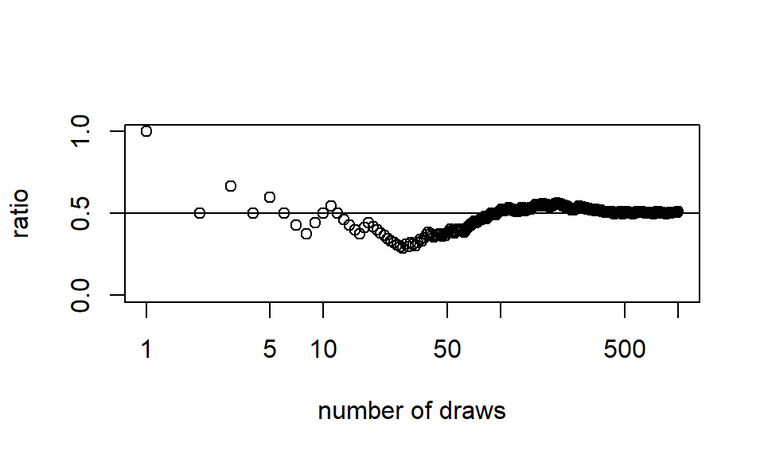

```r
n <- 1000
p = 0.5
set.seed(12321)
sample <- rbinom(n,1,p)
y <- cumsum(sample)/1:n
plot(y, log='x',xlab = "number of draws",ylab="ratio",ylim=c(0,1), yaxt='n')
axis(side = 2, at=c(0,0.5,1))
abline(p,0)
```

2. **Subjective**: A decision maker is willing to bet based on odds $p$

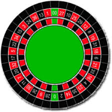

- We follow the **subjective** interpretation. It is more general and does not require repeatable experiments.

## Subjective expected utility

- Probabilities are more than a mathematical toy
- We can connect them to decision-making
- Let’s consider
  - an action $a$
    - Example: crossing the street, a = “cross” or a = “wait”
  - an uncertain event $y$
    - $y$ = “car” or $y$ = “no car”
  - a resulting consequence $c(a,y)$
    - c(wait, no car) = unchanged
    - c(wait, car) = unchanged
    - c(cross, no car) = success
    - c(cross, car) = injury
- How can we decide what action to take?!

### Utility over consequences

- First, a standard result from micro theory
- Let’s say you have preferences $\gtrsim$ over the consequences
  - Reasonable assumption: success $\gtrsim$ unchanged $\gtrsim$ injury
- If preferences are
  - **complete** (of two consequences, one is (weakly) preferred)
  - **transitive** (if $c_3$ $\gtrsim$ $c_2$ & $c_2$ $\gtrsim$ $c_1$, then $c_3$ $\gtrsim$ $c_1$)

  there exists a utility function $u$ representing them

  $u(c_1) \ge u(c_2) \quad \iff \quad c_1 \gtrsim c_2$
- utility functions can explain choices over consequences, but we want to choose between the actions “crossing” and “waiting” in the presence of uncertainty about “car” and “no car”

we look at finite number of consequences ignoring some of the technical details that otherwise arise

### Utility with uncertainty: Expected utility

- Now we want to extend the utility framework to include uncertainty about the state of the world (above it is uncertain if a car will come)
- There are two popular ways to extend the utility framework to uncertainty
  1. subjective approach (more complicated, but arguably more general)
  2. objective approach (relying on the assumption that objective probabilities exist, more elegant)
- We follow the subjective approach (but leave out a lot of technical details)

### Setting

- There are unknown states of the world $s_1$,$s_2$,…
  - in example: $s_1=$“car”, $s_2$=“no car”
  - events $E$ are sets of states
- There are actions $f$,$g$,$h$…
  - mapping each state to a consequence $f(s)=c$
  - in example: crossing(“car”) = injury, crossing(“no car”) = success
- Definition: $fEg$ defines action that results in $f$ if $E$ happens and in $g$ otherwise
  - basically: Do f if event E and g otherwise
- We want to analyse preferences (choices) over actions
  - in example: crossing $\overset{?}{\gtrsim}$ waiting

Actions are often called acts in the literature.

### Axioms

- for preferences over actions, we consider the following axioms
- **completeness** and **transitivity**
- **independence**: if actions constant on “not E”, preference are independent of this part
  $$fEg \gtrsim f'Eg \iff fEg' \gtrsim f'Eg'$$
- **state neutrality**: ranking of constant acts is independent of the event they are conditioned on
  $$c_2 \gtrsim c_1 \iff c_2Ef \gtrsim c_1Ef$$
- **likelihood consistency**: the ranking of events by likelihood does not depend on which consequences are used to elicit it
  $$\text{If } c_2 \gtrsim c_1 \text{ and } c'_2 \gtrsim c'_1 \text{ then } c_1Ec_2 \gtrsim c_1Fc_2 \iff c'_1Ec'_2 \gtrsim c'_1Fc'_2$$

plus some technical axioms we omit here

### Expected utility representation

For a probability distribution $\pi$ and a utility function $u$, define the expected utility by
$$U_\pi^u(f)=E_{s\sim \pi}[u(f(s))]$$

**CautionDefinition: Expected utility representation.**

We say that preferences $\gtrsim$ can be represented by an expected utility, if there exists a expected utility $U_\pi^u$ such that
$$f \gtrsim g \quad \iff \quad U_\pi^u(f) \ge U_\pi^u(g)$$

### Axioms imply SEU

**TipTheorem (Savage 1954).**

If the axioms above (and some technical ones) hold for preferences $\gtrsim$, the preferences $\gtrsim$ can be represented by an expected utility.

- Probabilities can be derived from preferences and axioms alone!
- Following the axioms is the same as
  1. having a utility over consequences and
  2. a probability distribution over unknown states
  3. choosing between actions based on their expected utility

### Summary

- Subjective expected utility
  - every decision problem can be divided into two parts
    - 1: Consequences and their utility value
    - 2: probabilities over uncertain states
  - rational decision-making just means to
    - 1: understand your preferences
    - 2: form probability predictions
  - In this lecture, we focus on part 2 above: How should we form “good” probabilities?
  - consequences and utilities depend on the situation

## Information and Bayesian learning

- So far we looked at a static situation
- What happens if we receive **new information**?
  - in the example: We look and see a SUV approaching
- How should our **action depend on new information**?
  - how should we change our subjective probabilities?

### Setting

- We extend our example to one with a larger state space with
  - $s_1 = (SUV, stop)$, $s_2 = (SUV, overrun)$
  - $s_3 = (\text{no SUV}, stop)$, $s_4 = (\text{no SUV}, overrun)$
- Consider two preferences:
  - $\gtrsim$ denotes the preferences **before information**, and
  - $\gtrsim_A$ **after observing** that true state lies in $A$.
  - in example: $A=\{s_1,s_2\}$ (it’s a SUV, but unclear if stop or overrun)

### Axioms

**CautionAxiom 1 (Consequentialism).**

If $f = g$ on $A$, then $f \sim_A g$.

- consequentialism: Consequences beyond $A$ do not matter after observing $A$.
  - we do not care that an action would have been better for cases that cannot occure anymore

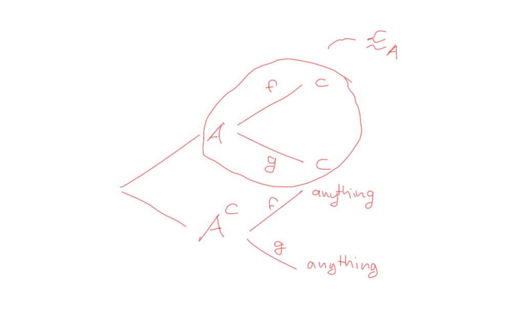

**CautionAxiom 2 (Dynamic Consistency).**

$f \gtrsim_A g \;\Longleftrightarrow\; fAg \gtrsim g$.

- after receiving information A, preferences cannot change for those acts that differed only inside $A$

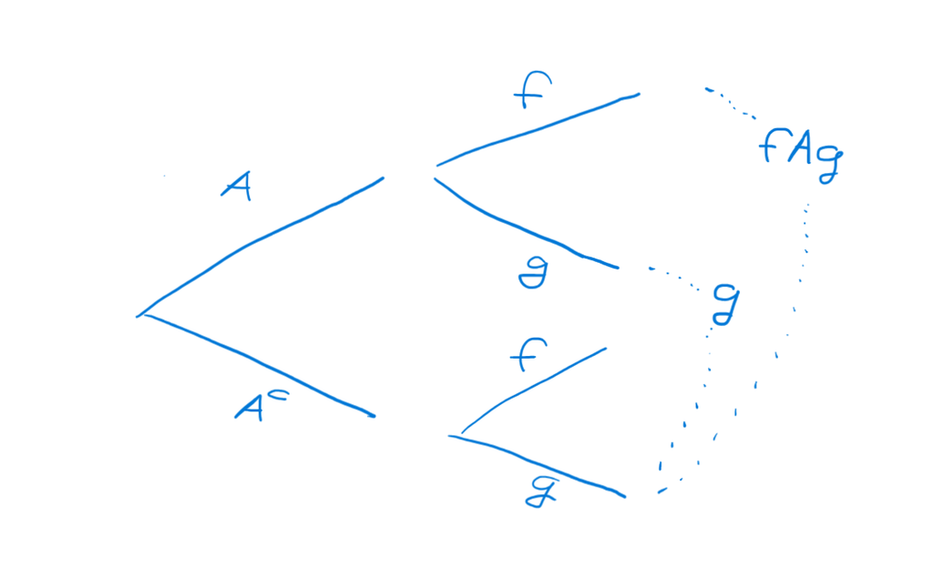

### Consequentialism and Dynamic consistency imply Bayesian updating

Assume that both $\gtrsim$ and $\gtrsim_A$ admit expected utility representations with utility $u$ and beliefs $\pi$ and $\pi_A$, respectively.

**TipTheorem (Bayesian updating).**

$\gtrsim_A$ and $\gtrsim$ satisfy **Consequentialism** and **Dynamic Consistency** if and only if $\pi_A(B) = \frac{\pi(A \cap B)}{\pi(A)}$.

### Toy example for Bayes rule

- Toy example:
  - 10 states $s_i$, $i=1,\dots,10$
  - with identical prior probability $\pi(s_i)=\frac 1 {10}$
  - $A = \{s_1,s_2,s_3,s_4,s_5\}$
  - $B = \{s_5\}$
- Bayes rule after observing set $A$:
  $$\pi_A(B) = \frac{\pi(A \cap B)}{\pi(A)}$$

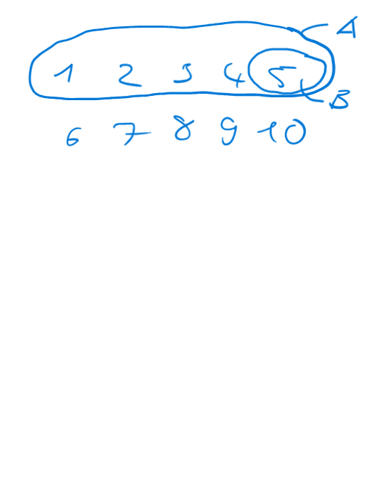

### Bayes rule in applications

- In most applications we have
  - a **prior** $P(B)$ given,
  - the **likelihood** $P(A|B)$ given, and
  - we want to compute the **posterior** $P(B|A)$
- Bayes rule
  $$P(B|A) = \frac {P(A \cap B)} {P(A)}$$
  - we can compute those terms with the **prior** and the **likelihood**
    $$P(A\cap B)= P(A|B) P(B)$$
    and
    $$\begin{align*}
    P(A) &= P(A\cap B) + P(A \cap \text{not } B)\\
    &= P(A|B) P(B) + P(A|\text{not } B) P(\text{not } B)
    \end{align*}$$

### Example: Monty-Hall-Problem

[figure not shown]

  You’re on a game show, and given the choice of three doors: Behind one door is a car; behind the others, goats. You pick a door and the host, who knows what’s behind the doors, opens another door which has a goat. He then says choose again. Is it to your advantage to switch?
- After an article in Parade magazin approximately 10,000 readers, including nearly 1,000 with PhDs, wrote to the magazine, most of them calling the solution wrong
- Paul Erdős, a famous mathematician, remained unconvinced until shown a computer simulation
- shows how unintuitve Bayesian updating can be

Solution:

- states: car in 1,2 or 3
- you chose door 1 (without loss of generality)
- host opens door 3 (without loss of generality)
- want to know $p(\text{car 1} | \text{host 3})$
- likelihood:
  - $p(\text{host 3} | \text{car 1}) = 1/2$
  - $p(\text{host 3} | \text{car 2}) = 1$
  - $p(\text{host 3} | \text{car 3}) = 0$
- prior: $p(\text{car i}) = \frac 1 3$
  $$\begin{align*}
  p(\text{car 1}|\text{host 3})&=\frac {p(\text{car 1, host 3}) }{ p(\text{host 3}) } = \\
  &= \frac {p(\text{host 3} | \text{car 1})* p(\text{car 1})} {\sum_i p(\text{host 3} | \text{car i})* p(\text{car i})}\\
  &= \frac {1/2 \times 1/3} {1 \times 1/3 + 1/2 \times 1/3}
  =\frac {1/2 } {1 + 1/2}=1/3
  \end{align*}$$

### Modern Bayesian workflow

- Task: Predict some outcome (e.g., needed hospital beds during Covid pandemic)
- Bayesian workflow (data $D$):
  1. Define a model with parameter $\theta$ that implies a likelihood $P(D|\theta)$
  2. Elicit prior probabilities $P(\theta)$
  3. Approximate posterior probability
     $$P(\theta|D) = \frac {P(D \cap \theta)}{P(D)}\propto {P(D|\theta)P(\theta)}$$
     with algorithm
  4. Use posterior and model to predict new data
- Advantage:
  - full treatment of uncertainty
  - “rational” because Bayesian
- Disadvantage:
  - often computationally complex
  - needs priors

### A word on priors

- controversial topic
  - other estimators (like the OLS estimator for regressions) do not rely on priors
  - priors are subjective (what if people disagree?)
- In some technical sense: Every well-behaved estimator is the posterior to a prior (Complete class theorem)
  - so every non-Bayesian estimator is essentially based on a prior
- Applied work often relies on “uninformative priors”

### Summary

- Under new information, updating your prior by Bayes rule is optimal (in some specific sense)
  - The axioms of dynamic consistency and consequentialism imply Bayesian updating
- Remaining challenge:
  - How do we get to a prior? (wait for Part II: Judgmental predictions)
  - How do we compute the Bayes posterior for complex models? (wait for Part III: Statistical predictions)
- Next, we see how good predictions look like
  - We study how do probabilities look like that lead to higher utility

# Other stuff

### Complete class theorem

for every admissible decision function, there exists a prior distribution, such that the optimal decision is a bayes decision function.

ML slides from Kasy [(link)](https://maxkasy.github.io/home/files/teaching/ML_Oxford_2023/decision_theory_slides.pdf)